# Advanced usage of BioCor

Lluís Revilla

IDIBAPS; Liver Unit, Hospital Clinic; Universitat Pompeu Fabra

lluis.revilla@gmail.com

31 julio 2017

#### Abstract

Describes how to use the BioCor package to answer several biological questions and how to use functional similarities with other measures.

#### Package

BioCor 1.1.4

# 1 Assesing a differential study

In this example we will use the functional similarities in a classical differential study.

## 1.1 Obtaining data

We start using data from the [RNAseq workflow](http://bioconductor.org/help/workflows/rnaseqGene/#differential-expression-analysis) and following the analysis:

```r
suppressPackageStartupMessages(library("airway"))
data("airway")
library("DESeq2")

dds <- DESeqDataSet(airway, design = ~ cell + dex)
dds$dex <- relevel(dds$dex, "untrt")
dds <- DESeq(dds)
## estimating size factors
## estimating dispersions
## gene-wise dispersion estimates
## mean-dispersion relationship
## final dispersion estimates
## fitting model and testing
res <- results(dds, alpha = 0.05)
summary(res)
```

```
##
## out of 33469 with nonzero total read count
## adjusted p-value < 0.05
## LFC > 0 (up)     : 2211, 6.6%
## LFC < 0 (down)   : 1817, 5.4%
## outliers [1]     : 0, 0%
## low counts [2]   : 16676, 50%
## (mean count < 7)
## [1] see 'cooksCutoff' argument of ?results
## [2] see 'independentFiltering' argument of ?results
```

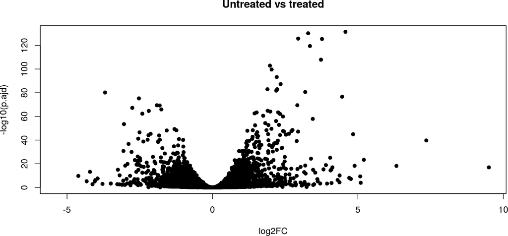

Figure 1: Volcano plot  
The airway data

```r
plot(res$log2FoldChange, -log10(res$padj), pch = 16, xlab = "log2FC",
     ylab = "-log10(p.ajd)", main = "Untreated vs treated")
```

As we can see here there are around 4000 genes differentially expressed genes

## 1.2 Testing the different methods

First we need to know how similar are the genes in the several methods :

```r
library("org.Hs.eg.db")
```

```r
genes <- mapIds(org.Hs.eg.db, keys = rownames(res), keytype = "ENSEMBL", column = "ENTREZID")
## 'select()' returned 1:many mapping between keys and columns
genesI <- names(genes)
names(genesI) <- genes
library("BioCor")
## If you use BioCor in published research, please cite:
library("reactome.db")
genesReact <- as.list(reactomeEXTID2PATHID)
fc3 <- res[abs(res$log2FoldChange) >= 3 & !is.na(res$log2FoldChange), ]
genesFC3 <- genes[rownames(fc3)]
names(genesFC3) <- NULL
m <- c("avg", "max", "rcmax", "rcmax.avg", "reciprocal")
methods <- sapply(m, mgeneSim, genes = genesFC3, info = genesReact, simplify = FALSE)
## Warning in FUN(X[[i]], ...): Some genes are not in the list provided.

## Warning in FUN(X[[i]], ...): Some genes are not in the list provided.

## Warning in FUN(X[[i]], ...): Some genes are not in the list provided.

## Warning in FUN(X[[i]], ...): Some genes are not in the list provided.
```

Once we have calculated the similarity for the genes we can now visualize the effect of each method:

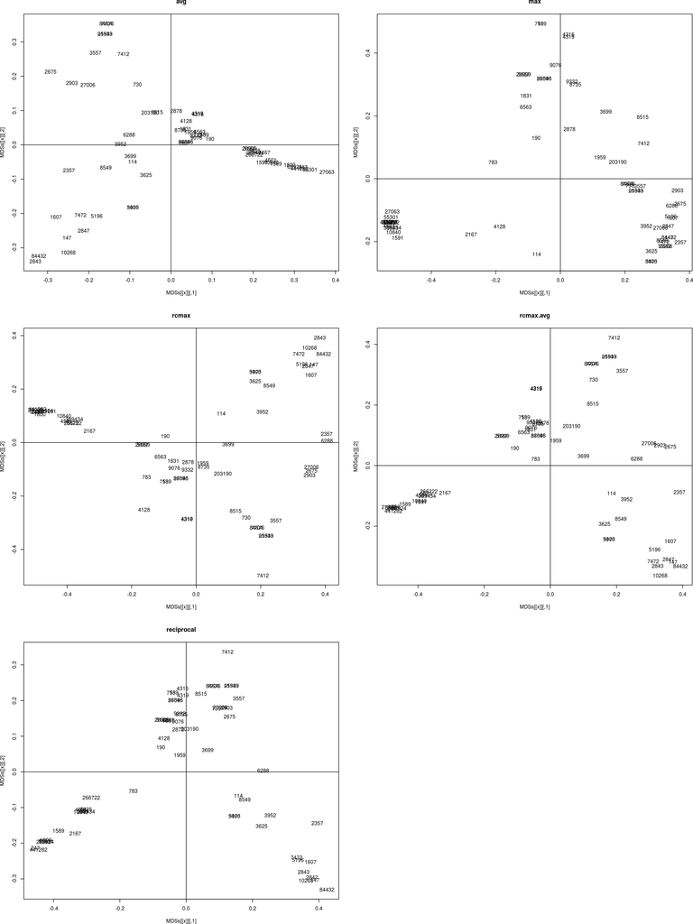

Figure 2: Functional similarity of genes  
Different methods results in different similarities.

```r
MDSs <- sapply(methods, function(x){
    gS <- x
    gS <- gS[rowSums(is.na(gS)) != ncol(gS), rowSums(is.na(gS)) != ncol(gS)]
    tryCatch({cmdscale(1-gS)}, error = function(x){NA}, warning=function(x){NA})
    # Reciprocal method ends with NA and thus is unable to calculate cmdscale
}, simplify = FALSE)
par(mfrow = c(3, 2))
a <- sapply(names(MDSs), function(x){
    # plot(seq(-1, 1, by = 0.25), seq(-1, 1, by = 0.25), main = x, type = "n")
    plot(MDSs[[x]], type = "n", main = x)
    text(MDSs[[x]], labels =  rownames(MDSs[[x]]))
    abline(h = 0)
    abline(v = 0)
    })
```

*Note:* The position on the axis of this plots can be flipped.

In general all the methods output similar plots, except the “max” method. Also note that here we are only using 61 genes. The difference between the methods might be higher when using more genes.

## 1.3 Selecting differentially expressed genes

First to reduce the complexity we reduce to 400 genes with a known fold change to speed the calculations. The resulting plots must not be taken as an example of what it should happen or look like in a real analysis, they are just ilustrative.

```r
set.seed(220)
subRes <- res[!is.na(res$log2FoldChange), ]
subs <- sample.int(nrow(subRes), size = 400)
subRes <- subRes[subs, ]
g <- genes[rownames(subRes)]
# names(g) <- NULL
gS <- mgeneSim(g, genesReact, "BMA")
nrow(gS)
```

```
## [1] 226
```

```r
deg <- rownames(subRes[subRes$padj < 0.05 & !is.na(subRes$padj), ])
keep <- rownames(gS) %in% genes[deg]
```

Are genes differentially expressed more functional related than those which aren’t differential expressed?

We can answer this by testing it empirically:

```r
par(mfrow = c(1, 1))
library("boot")
(scoreB <- mean(gS[keep, !keep], na.rm = TRUE))
```

```
## [1] 0.118837
```

```r
b <- boot(data = gS, R = 1000, statistic= function(x, i){
    g <- !rownames(x) %in% rownames(x)[i]
    mean(x[g, i], na.rm = TRUE)
})
(p.val <- (1 + sum(b$t>scoreB))/1001)
```

```
## [1] 0.4435564
```

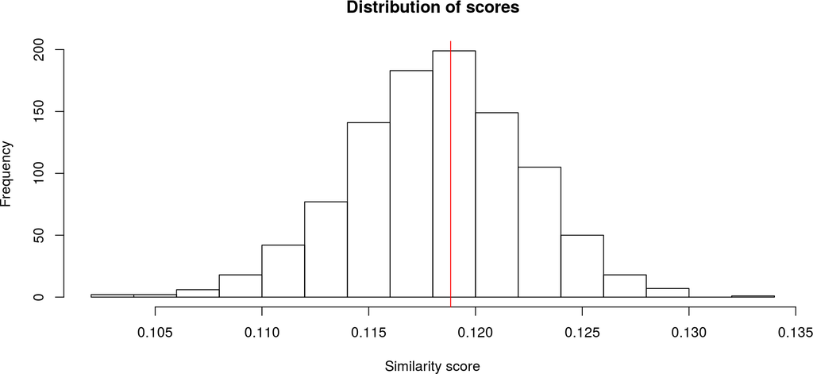

Figure 3: Gene clustering by similarities distribution

```r
hist(b$t, main = "Distribution of scores", xlab = "Similarity score")
abline(v=scoreB, col = "red")
```

Comparing the genes differentially expressed and those who aren’t doesn’t show that they are specially selected. *Note:* from 400 genes there are 226 with pathway information.

## 1.4 Are functionally related genes of my gene set?

One of the main questions is the significance of the pathways in the condition under the study. Here we show a method to answer a related question: are genes functionally related differentially expressed than those which aren’t?

```r
(scoreW <- combineScores(gS[keep, keep], "avg"))
```

```
## [1] 0.1631133
```

```r
b <- boot(data = gS, R = 1000, statistic= function(x, i){
    mean(x[i, i], na.rm = TRUE)
})
(p.val <- (1 + sum(b$t>scoreW))/1001) # P-value
```

```
## [1] 0.001998002
```

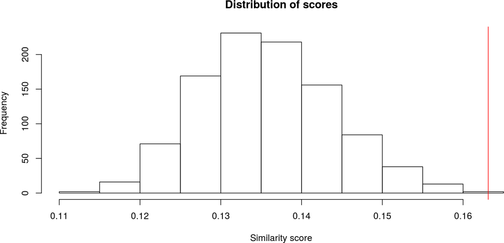

Figure 4: Distribution of the similarity between genes

```r
hist(b$t, main = "Distribution of scores", xlab = "Similarity score")
abline(v=scoreW, col = "red")
```

## 1.5 Influence of the fold change in the funtionally similarity of the genes

We have seen that the genes differentially expressed are not selected by functional similarity but never the less they are related functionally. Now we could want to know when does this similarity appear when selecting a fold change as threshold. To know the relationship between the fold change and the similarity between genes we have several methods:

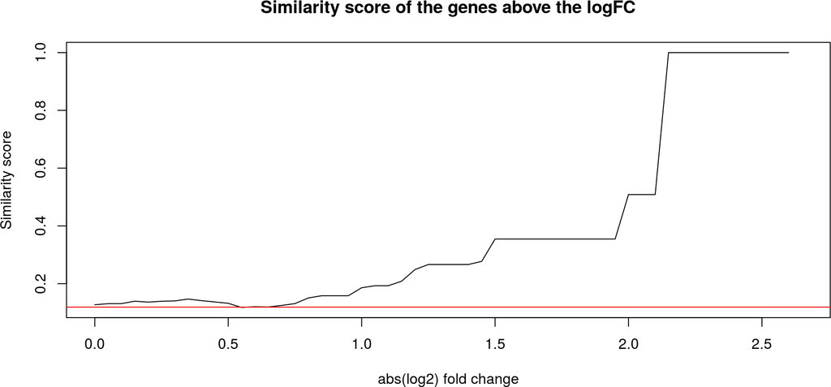

Figure 5: Similarity of genes above logFC  
Assessing the similarity of genes according to their absolute log2 fold change.

```r
s <- seq(0, max(abs(subRes$log2FoldChange))+0.05, by = 0.05)
l <- sapply(s, function(x){
    deg <- rownames(subRes[abs(subRes$log2FoldChange) >= x, ])
    keep <- rownames(gS) %in% genes[deg]
    mean(gS[keep, keep], na.rm = TRUE)
})
L <- cbind(logfc = s, value = l)
L <- as.data.frame(L)
plot(L$logfc, L$value, type = "l", xlab = "abs(log2) fold change", ylab = "Similarity score", main = "Similarity score of the genes above the logFC")
abline(h=scoreB, col = "red")
```

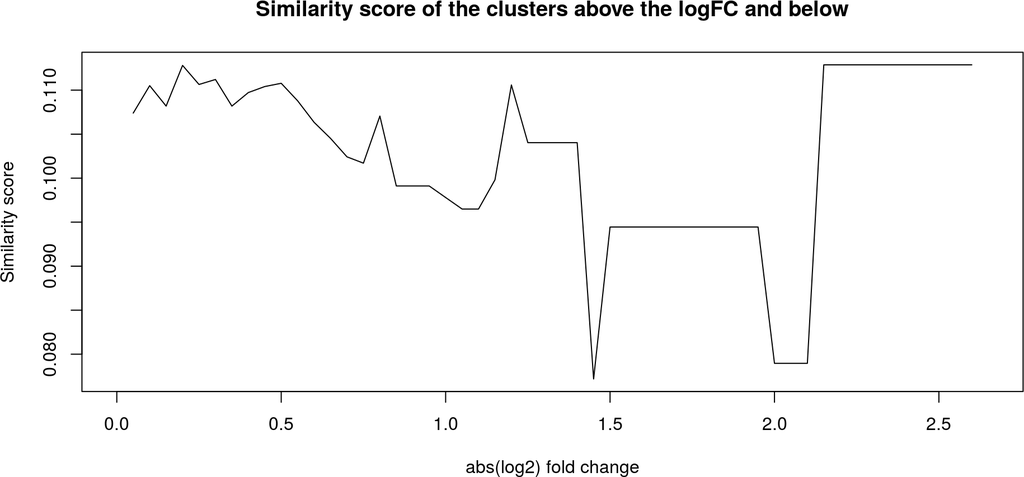

Figure 6: Gene clustering by similarities along logFC

```r
l <- sapply(s, function(x){
    deg <- rownames(subRes[abs(subRes$log2FoldChange) >= x, ])
    keep <- rownames(gS) %in% genes[deg]
    mean(gS[keep, !keep], na.rm = TRUE)
})
L <- cbind(logfc = s, value = l)
L <- as.data.frame(L)
plot(L$logfc, L$value, type = "l", xlab = "abs(log2) fold change", ylab = "Similarity score", main = "Similarity score of the clusters above the logFC and below")
abline(h=scoreW, col = "red")
```

Here we can observe that the logFC threshold doesn’t affect the similarity between genes differentially expressed and those who aren’t.

# 2 Assesing a new pathway

We can test how does the network of genes change if we add a new pathway, for instance we have a new pathway with the genes of deg:

```r
# Adding a new pathway "deg" to those genes
genesReact2 <- genesReact
genesReact2[genes[deg]] <- sapply(genesReact[genes[deg]], function(x){c(x, "deg")})
plot(ecdf(mgeneSim(names(genesReact), genesReact)))
curve(ecdf(mgeneSim(names(genesReact2), genesReact2)), color = "red")
```

This would take lot of time, for a ilustration purpose we reduce to a list of genes:

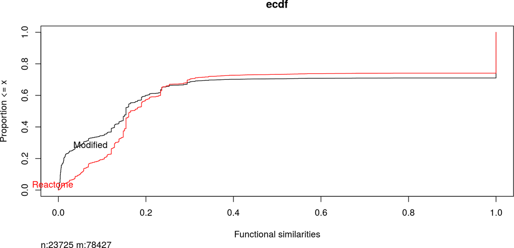

```r
library("Hmisc")
genesReact2 <- genesReact
genesReact2[genes[deg]] <- sapply(genesReact[genes[deg]], function(x){c(x, "deg")})
Ecdf(c(mgeneSim(unique(genes[rownames(subRes)]), genesReact),
       mgeneSim(unique(genes[rownames(subRes)]), genesReact2)),
     group = c(rep("Reactome", length(gS)), rep("Modified", length(gS))),
     col = c("black", "red"), xlab = "Functional similarities", main = "ecdf")
```

# 3 Merging source of information

We can compare and evaluate what happens when we mix sources of pathways:

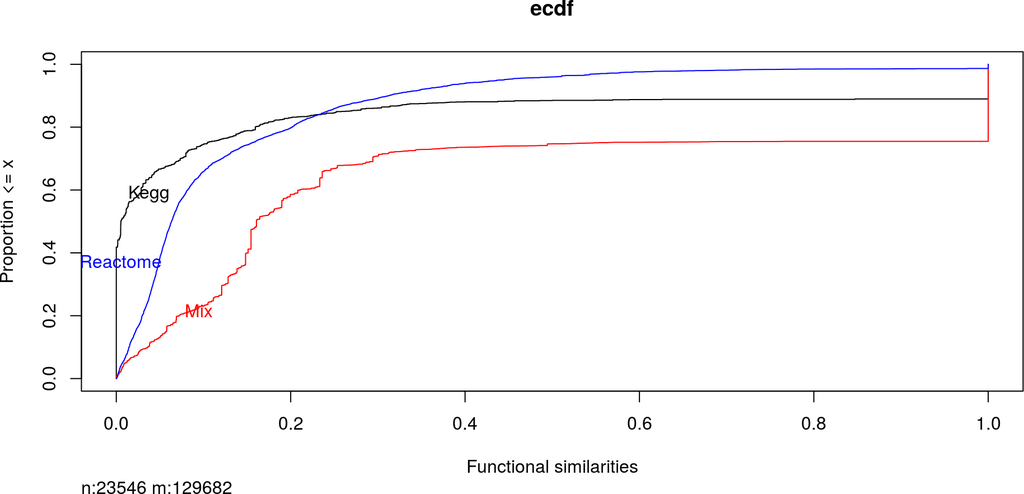

Figure 8: Comparison of functional similarity in different databases

```r
genesKegg <- as.list(org.Hs.egPATH)
gSK <- mgeneSim(rownames(gS), genesKegg)
mix <- combineSources(genesKegg, genesReact)
gSMix <- BioCor::mgeneSim(rownames(gS), mix)
Ecdf(c(gS, gSK, gSMix),
     group = c(rep("Reactome", length(gS)), rep("Kegg", length(gSK)),
               rep("Mix", length(gSMix))),
     col = c("black", "red", "blue"), xlab = "Functional similarities", main = "ecdf")
```

When mixed, there is a huge increase in the genes that share a pathway.

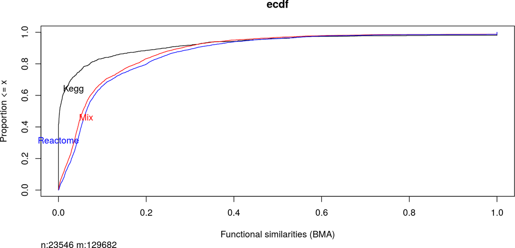

Figure 9: Comparison of functional similarity in different gene sets

```r
gSK2 <- BioCor::mgeneSim(rownames(gS), genesKegg, method = "BMA")
gS2 <- BioCor::mgeneSim(rownames(gS), genesReact, method = "BMA")
gSMix2 <- BioCor::mgeneSim(rownames(gS), mix, method = "BMA")
Ecdf(c(gS2, gSK2, gSMix2),
     group = c(rep("Reactome", length(gS)), rep("Kegg", length(gSK)),
               rep("Mix", length(gSMix))),
     col = c("black", "red", "blue"), xlab = "Functional similarities (BMA)", main = "ecdf")
```

Now we can appreciate that most of the functional similarity is brought by Reactome database

# 4 miRNA analysis

In this section we try to answer how functionally similar are two miRNA. This preparation has Been adapted from a [previous discussion](https://support.bioconductor.org/p/48138/#48236):

```r
library("targetscan.Hs.eg.db")
## select human mirna
humanMirnaIdx <- grep("hsa", mappedkeys(targetscan.Hs.egMIRNA))
## select seed-based families for human mirna
humanMirna <- mappedkeys(targetscan.Hs.egMIRNA)[humanMirnaIdx]
## select targets of families
humanMirnaFamilies <- unlist(mget(humanMirna, targetscan.Hs.egMIRBASE2FAMILY))
humanMirnaTargets <- mget(humanMirnaFamilies, revmap(targetscan.Hs.egTARGETS))
names(humanMirnaTargets) <- humanMirna
# Restrict to miRNA with more than one target and less than 150
miRNAs <- sample(humanMirnaTargets[lengths(humanMirnaTargets) > 1 &
                                       lengths(humanMirnaTargets) < 150], 10)
lengths(miRNAs)
```

```
##    hsa-miR-184 hsa-miR-127-3p   hsa-miR-551b    hsa-miR-210    hsa-miR-100
##             54             17             17             70             92
##    hsa-miR-126   hsa-miR-487b   hsa-miR-450a    hsa-miR-99b    hsa-miR-191
##             43             23             24             92            118
```

Now we have selected our miRNAs we can compare them using a cluster approach.

```r
cluster1 <- BioCor::mclusterSim(miRNAs, genesReact, method = "BMA")
cluster1[1:10, 1:5]
```

```
##                hsa-miR-184 hsa-miR-127-3p hsa-miR-551b hsa-miR-210
## hsa-miR-184      1.0000000      0.4536753    0.6386756   0.6858648
## hsa-miR-127-3p   0.4536753      1.0000000    0.4038545   0.4620425
## hsa-miR-551b     0.6386756      0.4038545    1.0000000   0.8446344
## hsa-miR-210      0.6858648      0.4620425    0.8446344   1.0000000
## hsa-miR-100      0.6065988      0.3608369    0.6105421   0.6780549
## hsa-miR-126      0.6324543      0.3536476    0.7345057   0.7270759
## hsa-miR-487b     0.6169659      0.4234633    0.7844957   0.7657335
## hsa-miR-450a     0.6246962      0.4119893    0.7943431   0.7813841
## hsa-miR-99b      0.6065988      0.3608369    0.6105421   0.6780549
## hsa-miR-191      0.5860631      0.3619366    0.6853514   0.7368277
##                hsa-miR-100
## hsa-miR-184      0.6065988
## hsa-miR-127-3p   0.3608369
## hsa-miR-551b     0.6105421
## hsa-miR-210      0.6780549
## hsa-miR-100      1.0000000
## hsa-miR-126      0.6567126
## hsa-miR-487b     0.7057688
## hsa-miR-450a     0.6701202
## hsa-miR-99b      1.0000000
## hsa-miR-191      0.7001820
```

# 5 Comparing with GO similarities

As suggested in the main vignette functional similarities can be compared to semantic similarities such as those based on GO. Here I will make a comparison using the biological process:

```r
library("GOSemSim")
```

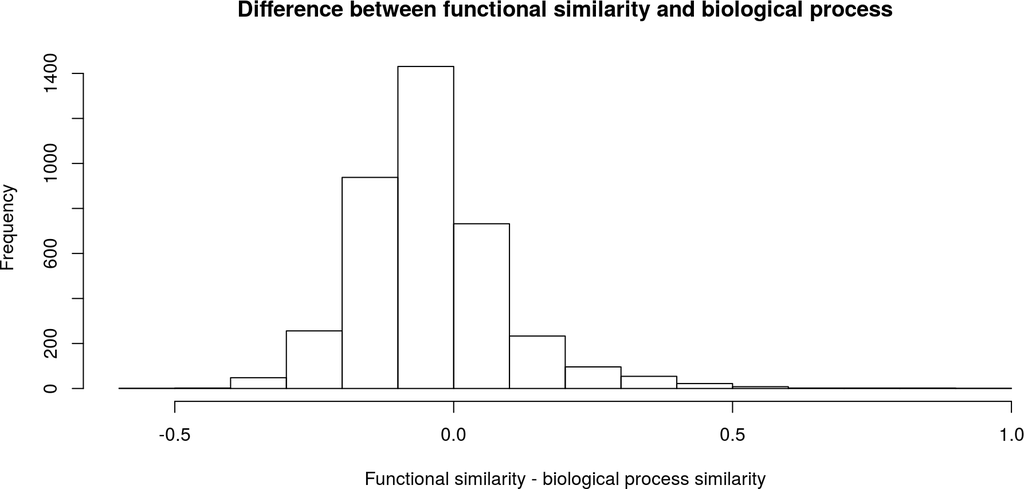

Figure 10: Comparison of similarities  
Functional similarities compared to biological process semantic similarity.

```r
BP <- godata('org.Hs.eg.db', ont="BP", computeIC=TRUE)
## preparing gene to GO mapping data...
## preparing IC data...
gsGO <- GOSemSim::mgeneSim(rownames(gS), semData = BP, measure = "Resnik", verbose = FALSE)
keep <- rownames(gS) %in% rownames(gsGO)
hist(as.dist(gS[keep, keep]-gsGO),
     main = "Difference between functional similarity and biological process",
     xlab = "Functional similarity - biological process similarity")
```

As we can see in this example, genes with similar biological process tend to be on different functions. We can further compare with the different databases:

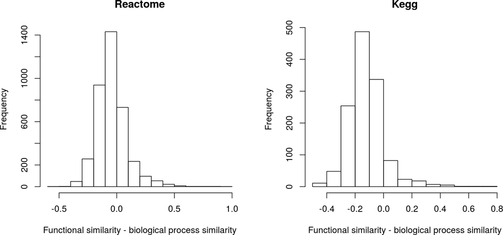

Figure 11: Histogram of functional similarities minus biological process similarities

```r
par(mfrow = c(1, 2))
hist(as.dist(gS2[keep, keep]-gsGO), main = "Reactome",
     xlab = "Functional similarity - biological process similarity")
hist(as.dist(gSK2[keep, keep]-gsGO), main = "Kegg",
     xlab = "Functional similarity - biological process similarity")
```